# Data621 Assignment 5

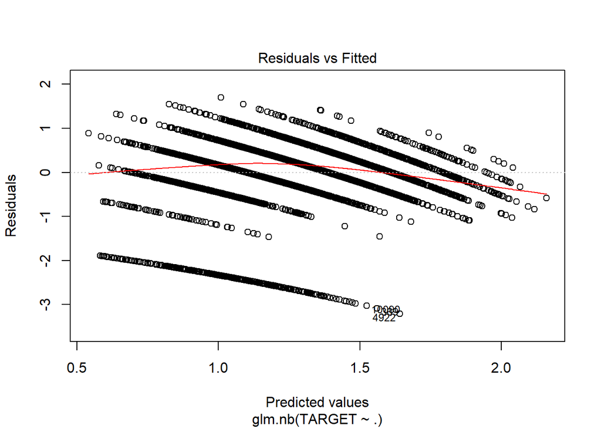

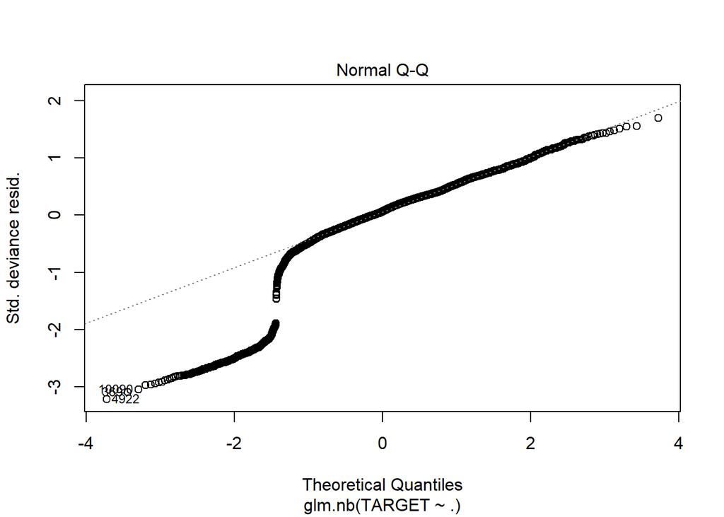

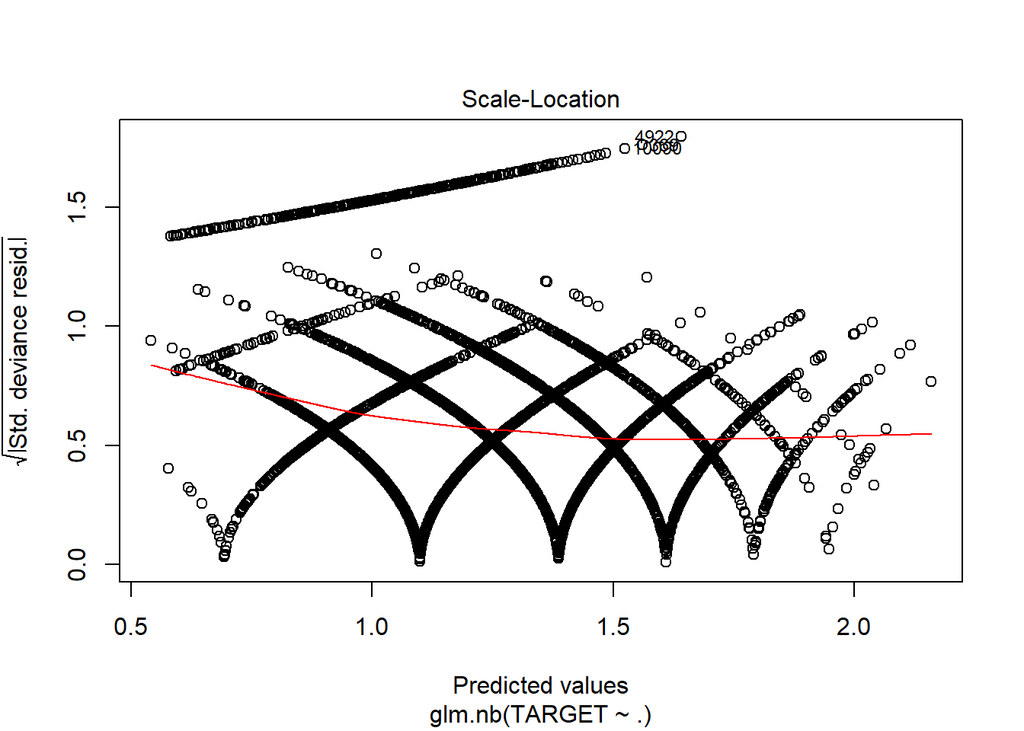

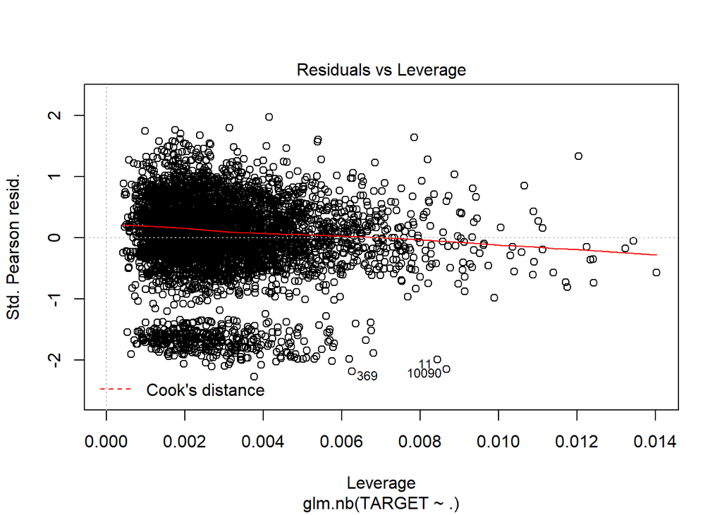

```r
plot(model5)
```

6. Negative Binomial without imputations and only significant variables:

```r
model6 <- glm.nb(TARGET ~ .-FixedAcidity-CitricAcid-ResidualSugar-Chlorides-FreeSulfurDioxide-TotalSulfurDioxide-Density-pH-Sulphates-Alcohol, data = wine_train1)
summary(model6)
```

```
##
## Call:
## glm.nb(formula = TARGET ~ . - FixedAcidity - CitricAcid - ResidualSugar -
##     Chlorides - FreeSulfurDioxide - TotalSulfurDioxide - Density -
##     pH - Sulphates - Alcohol, data = wine_train1, init.theta = 138402.5261,
##     link = log)
##
## Deviance Residuals:
##     Min       1Q   Median       3Q      Max
## -3.1898  -0.2777   0.0622   0.3764   1.6086
##
## Coefficients:
##                  Estimate Std. Error z value Pr(>|z|)
## (Intercept)      1.251443   0.054725  22.868  < 2e-16 ***
## VolatileAcidity -0.027581   0.009279  -2.973  0.00295 **
## LabelAppeal      0.173177   0.008853  19.562  < 2e-16 ***
## AcidIndex       -0.050616   0.006553  -7.724 1.13e-14 ***
## STARS            0.194209   0.008292  23.421  < 2e-16 ***
## ---
## Signif. codes:  0 '***' 0.001 '**' 0.01 '*' 0.05 '.' 0.1 ' ' 1
##
## (Dispersion parameter for Negative Binomial(138402.5) family taken to be 1)
##
##     Null deviance: 4720.4  on 5143  degrees of freedom
## Residual deviance: 3253.0  on 5139  degrees of freedom
##   (5093 observations deleted due to missingness)
## AIC: 18537
##
## Number of Fisher Scoring iterations: 1
##
##
##               Theta:  138403
##           Std. Err.:  258834
## Warning while fitting theta: iteration limit reached
##
##  2 x log-likelihood:  -18525.37
```

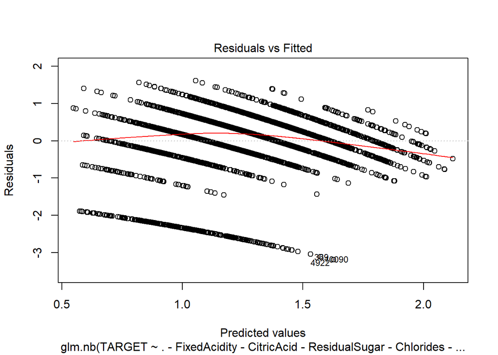

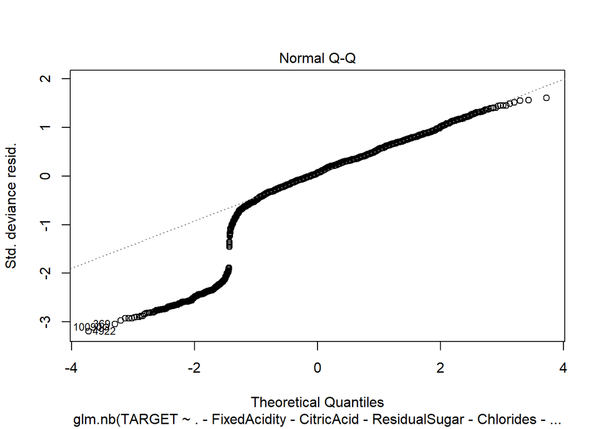

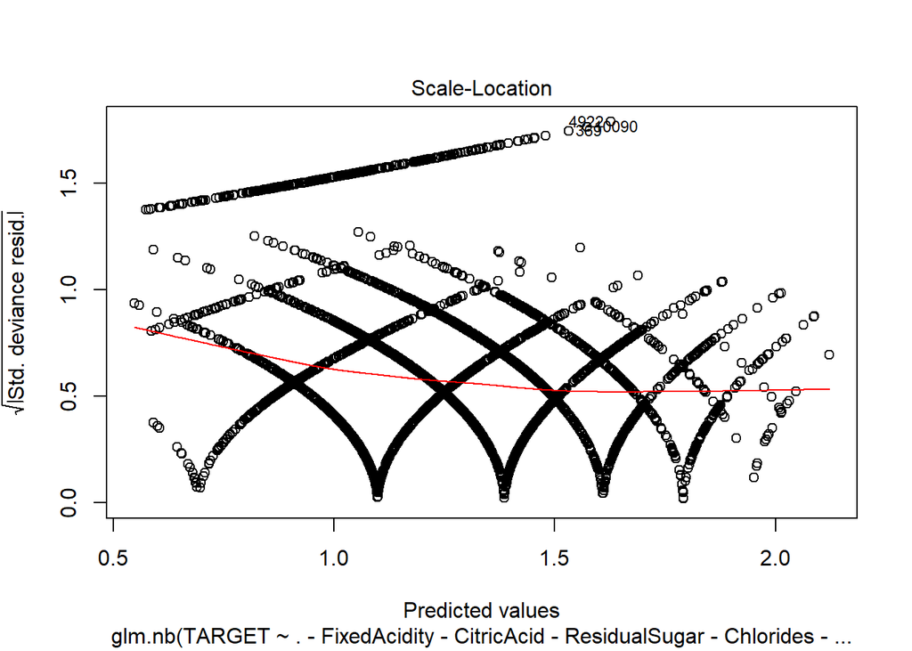

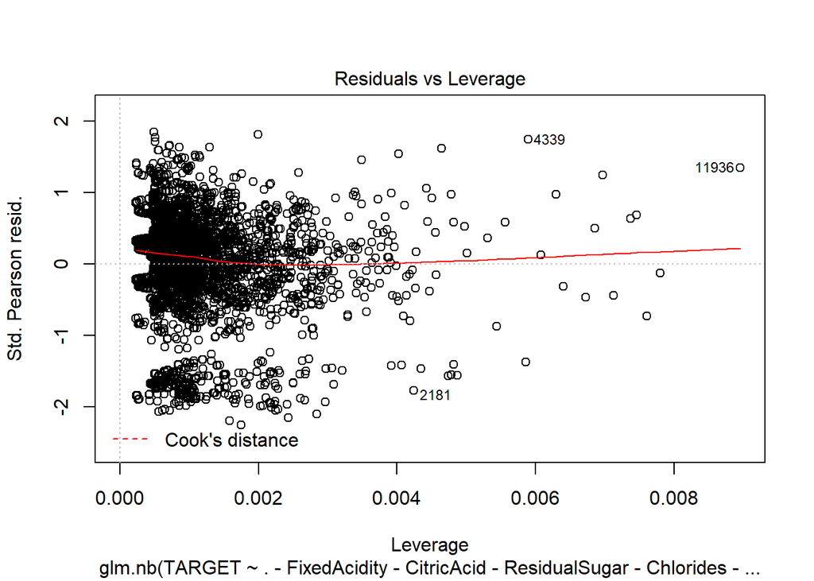

```r
plot(model6)
```

7. Negative Binomial with imputations:

```r
model7 <- glm.nb(TARGET ~ ., data = wine_train2)
summary(model7)
```

```
##
## Call:
## glm.nb(formula = TARGET ~ ., data = wine_train2, init.theta = 48897.24324,
##     link = log)
##
## Deviance Residuals:
##     Min       1Q   Median       3Q      Max
## -3.1515  -0.6808   0.1304   0.6390   2.4032
##
## Coefficients:
##                      Estimate Std. Error z value Pr(>|z|)
## (Intercept)         2.382e+00  2.277e-01  10.463  < 2e-16 ***
## FixedAcidity       -1.332e-04  9.197e-04  -0.145 0.884879
## VolatileAcidity    -4.351e-02  7.275e-03  -5.981 2.21e-09 ***
## CitricAcid          8.883e-03  6.577e-03   1.351 0.176804
## ResidualSugar       1.508e-04  1.675e-04   0.900 0.367960
## Chlorides          -6.506e-02  1.791e-02  -3.633 0.000280 ***
## FreeSulfurDioxide   1.143e-04  3.804e-05   3.005 0.002657 **
## TotalSulfurDioxide  8.709e-05  2.446e-05   3.560 0.000371 ***
## Density            -4.047e-01  2.141e-01  -1.890 0.058762 .
## pH                 -1.788e-02  8.407e-03  -2.126 0.033466 *
## Sulphates          -1.327e-02  6.164e-03  -2.153 0.031286 *
## Alcohol             2.690e-03  1.546e-03   1.740 0.081887 .
## LabelAppeal         1.432e-01  6.783e-03  21.106  < 2e-16 ***
## AcidIndex          -7.622e-01  4.005e-02 -19.029  < 2e-16 ***
## STARS               3.401e-01  6.252e-03  54.393  < 2e-16 ***
## ---
## Signif. codes:  0 '***' 0.001 '**' 0.01 '*' 0.05 '.' 0.1 ' ' 1
##
## (Dispersion parameter for Negative Binomial(48897.24) family taken to be 1)
##
##     Null deviance: 18290  on 10236  degrees of freedom
## Residual deviance: 12830  on 10222  degrees of freedom
## AIC: 38420
##
## Number of Fisher Scoring iterations: 1
##
##
##               Theta:  48897
##           Std. Err.:  63448
## Warning while fitting theta: iteration limit reached
##
##  2 x log-likelihood:  -38388.3
```

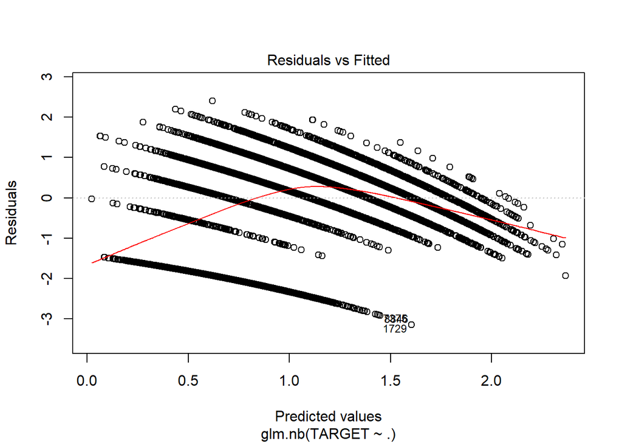

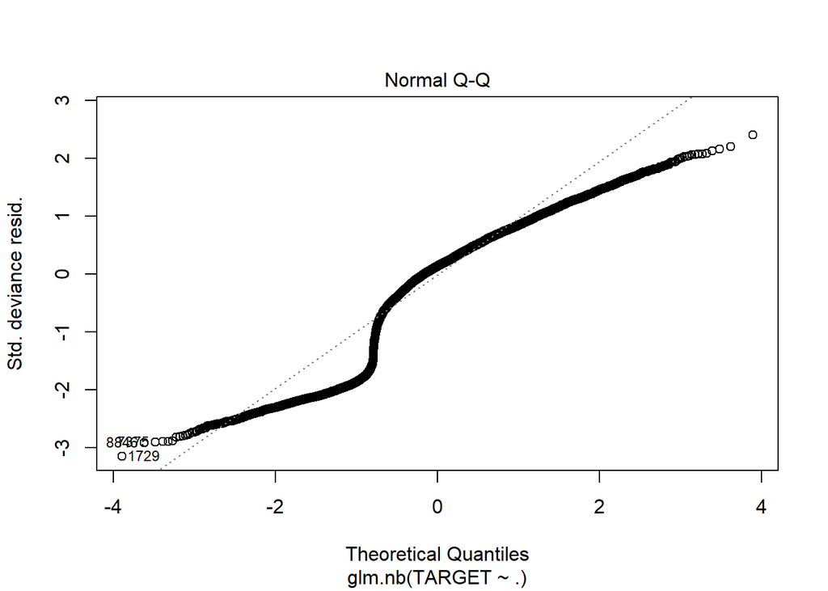

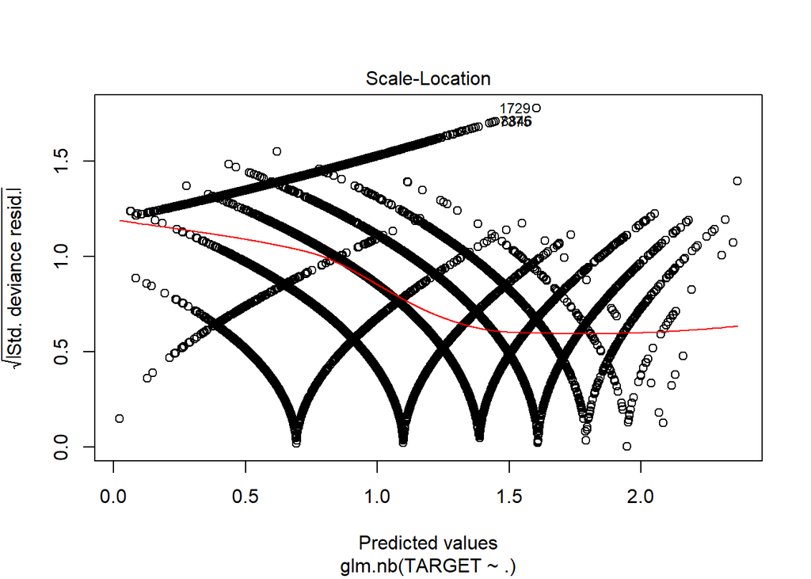

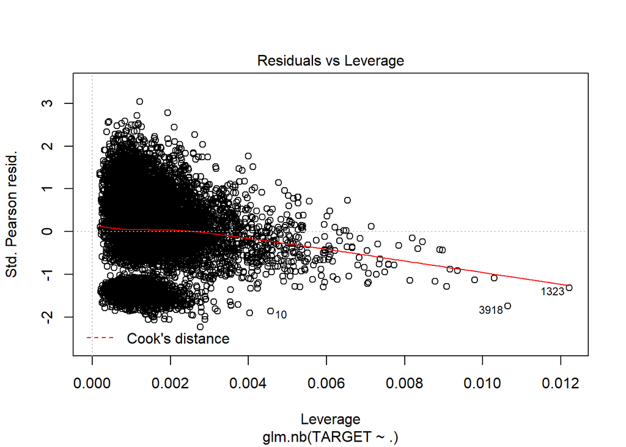

```r
plot(model7)
```

8. Negative Binomial with imputations and only significant variables:

```r
model8 <- glm.nb(TARGET ~ .-FixedAcidity-CitricAcid-ResidualSugar-Density-Alcohol, data = wine_train2)
summary(model8)
```

```
##
## Call:
## glm.nb(formula = TARGET ~ . - FixedAcidity - CitricAcid - ResidualSugar -
##     Density - Alcohol, data = wine_train2, init.theta = 48805.90033,
##     link = log)
##
## Deviance Residuals:
##     Min       1Q   Median       3Q      Max
## -3.1405  -0.6852   0.1288   0.6412   2.4038
##
## Coefficients:
##                      Estimate Std. Error z value Pr(>|z|)
## (Intercept)         2.019e+00  8.849e-02  22.820  < 2e-16 ***
## VolatileAcidity    -4.388e-02  7.273e-03  -6.033 1.61e-09 ***
## Chlorides          -6.711e-02  1.790e-02  -3.750 0.000177 ***
## FreeSulfurDioxide   1.119e-04  3.802e-05   2.942 0.003257 **
## TotalSulfurDioxide  8.561e-05  2.443e-05   3.505 0.000457 ***
## pH                 -1.818e-02  8.404e-03  -2.164 0.030489 *
## Sulphates          -1.327e-02  6.157e-03  -2.155 0.031144 *
## LabelAppeal         1.433e-01  6.783e-03  21.119  < 2e-16 ***
## AcidIndex          -7.665e-01  3.941e-02 -19.447  < 2e-16 ***
## STARS               3.410e-01  6.237e-03  54.671  < 2e-16 ***
## ---
## Signif. codes:  0 '***' 0.001 '**' 0.01 '*' 0.05 '.' 0.1 ' ' 1
##
## (Dispersion parameter for Negative Binomial(48805.9) family taken to be 1)
##
##     Null deviance: 18290  on 10236  degrees of freedom
## Residual deviance: 12839  on 10227  degrees of freedom
## AIC: 38420
##
## Number of Fisher Scoring iterations: 1
##
##
##               Theta:  48806
##           Std. Err.:  63368
## Warning while fitting theta: iteration limit reached
##
##  2 x log-likelihood:  -38397.65
```

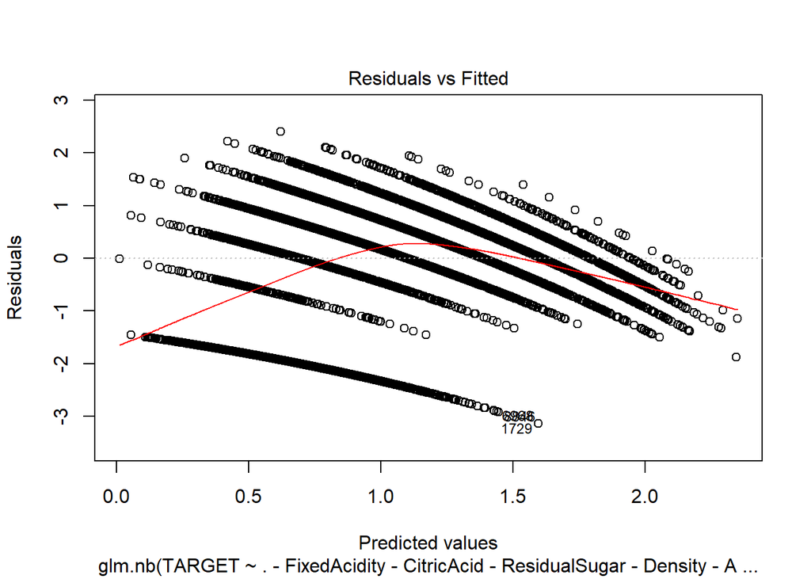

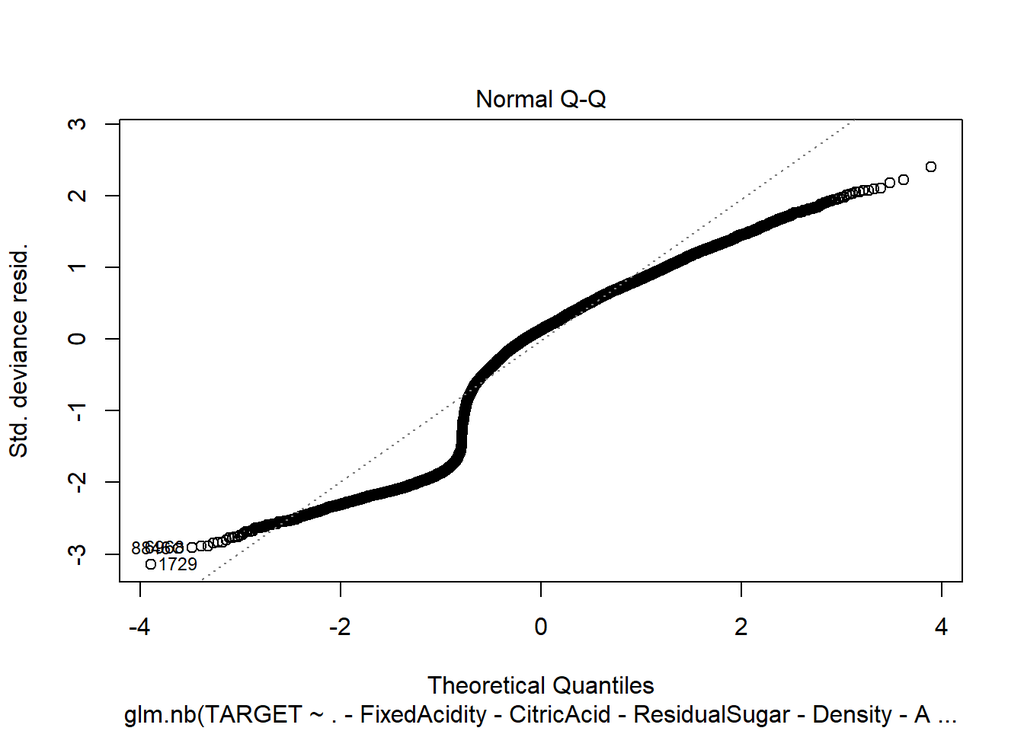

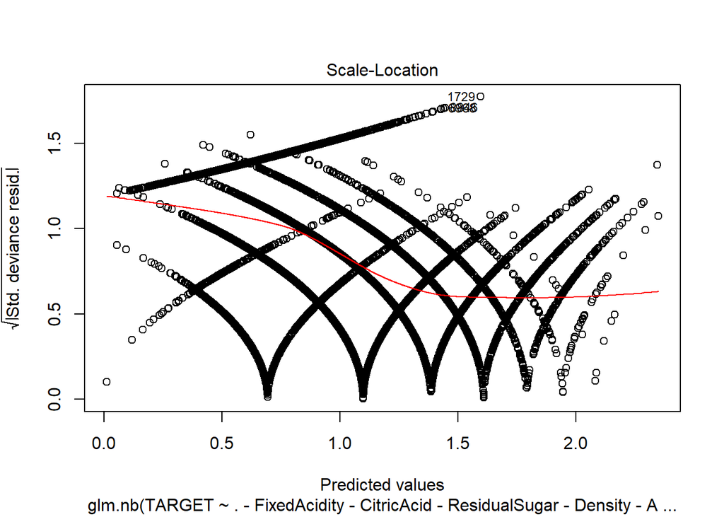

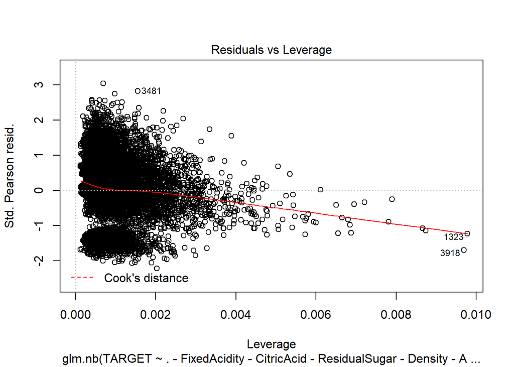

```r
plot(model8)
```

9. Linear Model with imputations.

```r
model9 <- lm(TARGET ~ ., data = wine_train2)
summary(model9)
```

```
##
## Call:
## lm(formula = TARGET ~ ., data = wine_train2)
##
## Residuals:
##     Min      1Q  Median      3Q     Max
## -4.6944 -1.0191  0.1692  1.0335  4.2502
##
## Coefficients:
##                      Estimate Std. Error t value Pr(>|t|)
## (Intercept)         6.149e+00  5.564e-01  11.052  < 2e-16 ***
## FixedAcidity       -1.428e-04  2.255e-03  -0.063  0.94952
## VolatileAcidity    -1.265e-01  1.792e-02  -7.056 1.82e-12 ***
## CitricAcid          2.771e-02  1.630e-02   1.699  0.08927 .
## ResidualSugar       4.479e-04  4.138e-04   1.083  0.27904
## Chlorides          -1.956e-01  4.398e-02  -4.448 8.77e-06 ***
## FreeSulfurDioxide   2.930e-04  9.398e-05   3.117  0.00183 **
## TotalSulfurDioxide  2.365e-04  6.006e-05   3.938 8.28e-05 ***
## Density            -1.099e+00  5.263e-01  -2.088  0.03678 *
## pH                 -4.064e-02  2.071e-02  -1.962  0.04978 *
## Sulphates          -3.621e-02  1.519e-02  -2.384  0.01713 *
## Alcohol             1.131e-02  3.782e-03   2.991  0.00279 **
## LabelAppeal         4.379e-01  1.644e-02  26.633  < 2e-16 ***
## AcidIndex          -2.041e+00  9.250e-02 -22.067  < 2e-16 ***
## STARS               1.162e+00  1.665e-02  69.754  < 2e-16 ***
## ---
## Signif. codes:  0 '***' 0.001 '**' 0.01 '*' 0.05 '.' 0.1 ' ' 1
##
## Residual standard error: 1.417 on 10222 degrees of freedom
## Multiple R-squared:  0.4598, Adjusted R-squared:  0.4591
## F-statistic: 621.5 on 14 and 10222 DF,  p-value: < 2.2e-16
```

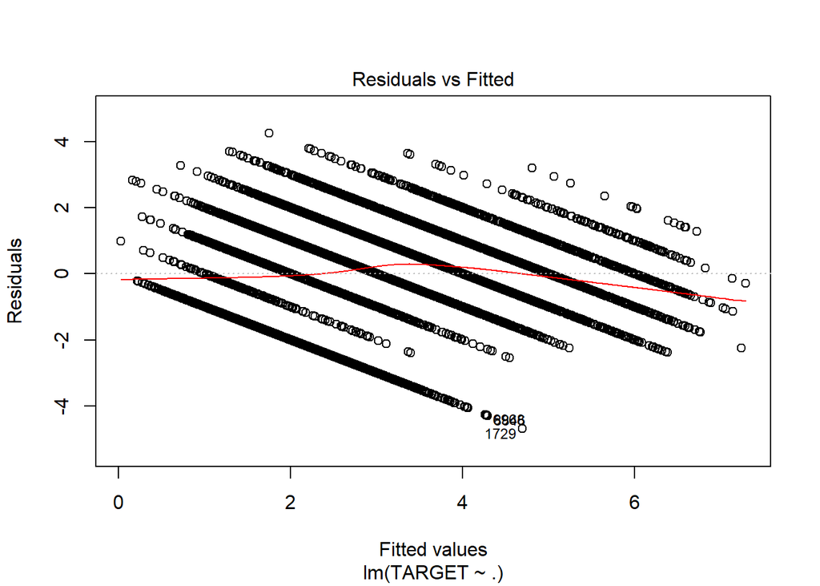

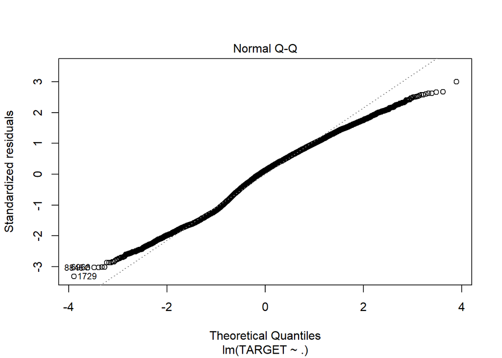

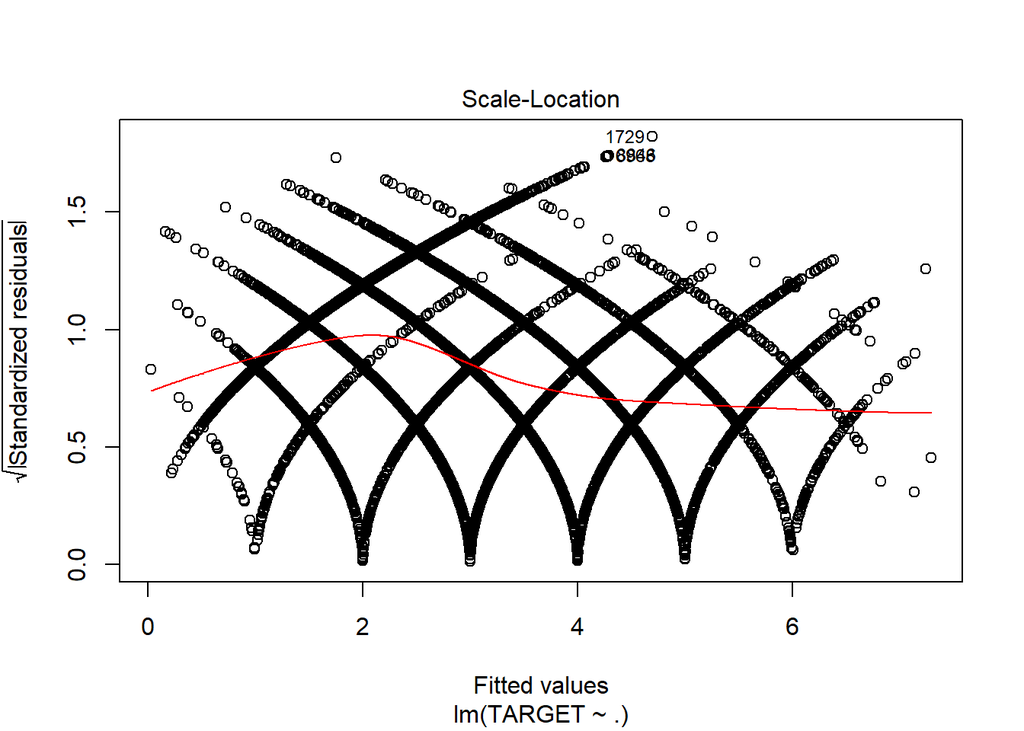

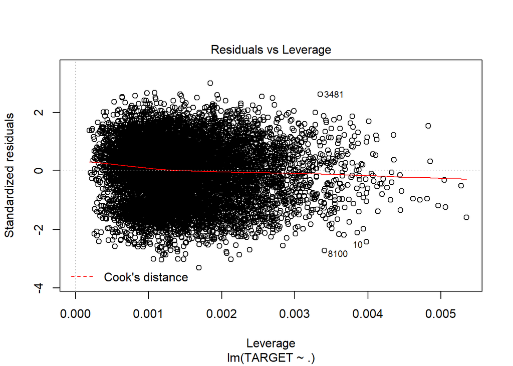

```r
plot(model9)
```

10. Linear Model with imputations and only significant variables.

```r
model10 <- lm(TARGET ~ .-FixedAcidity-CitricAcid-ResidualSugar, data = wine_train2)
summary(model10)
```

```
##
## Call:
## lm(formula = TARGET ~ . - FixedAcidity - CitricAcid - ResidualSugar,
##     data = wine_train2)
##
## Residuals:
##     Min      1Q  Median      3Q     Max
## -4.7075 -1.0195  0.1718  1.0343  4.2907
##
## Coefficients:
##                      Estimate Std. Error t value Pr(>|t|)
## (Intercept)         6.139e+00  5.563e-01  11.036  < 2e-16 ***
## VolatileAcidity    -1.273e-01  1.792e-02  -7.104 1.30e-12 ***
## Chlorides          -1.970e-01  4.397e-02  -4.479 7.57e-06 ***
## FreeSulfurDioxide   2.939e-04  9.397e-05   3.128  0.00177 **
## TotalSulfurDioxide  2.389e-04  6.003e-05   3.980 6.94e-05 ***
## Density            -1.101e+00  5.263e-01  -2.093  0.03638 *
## pH                 -4.059e-02  2.071e-02  -1.960  0.05008 .
## Sulphates          -3.699e-02  1.517e-02  -2.437  0.01481 *
## Alcohol             1.136e-02  3.781e-03   3.005  0.00266 **
## LabelAppeal         4.379e-01  1.644e-02  26.632  < 2e-16 ***
## AcidIndex          -2.031e+00  9.085e-02 -22.351  < 2e-16 ***
## STARS               1.162e+00  1.665e-02  69.794  < 2e-16 ***
## ---
## Signif. codes:  0 '***' 0.001 '**' 0.01 '*' 0.05 '.' 0.1 ' ' 1
##
## Residual standard error: 1.417 on 10225 degrees of freedom
## Multiple R-squared:  0.4596, Adjusted R-squared:  0.459
## F-statistic: 790.6 on 11 and 10225 DF,  p-value: < 2.2e-16
```

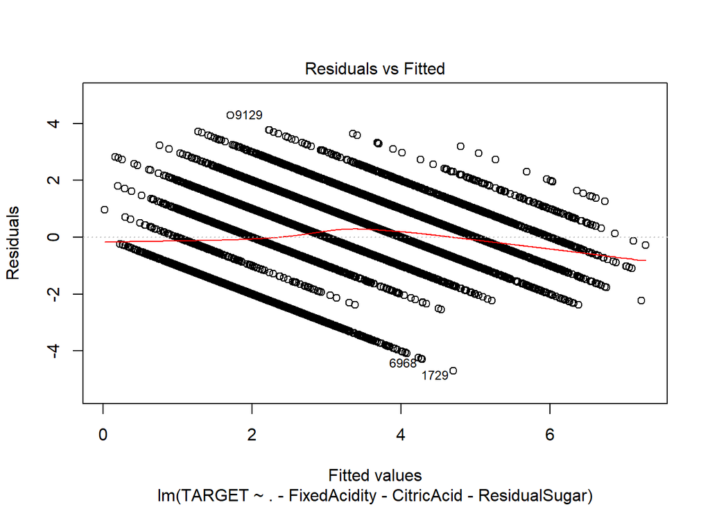

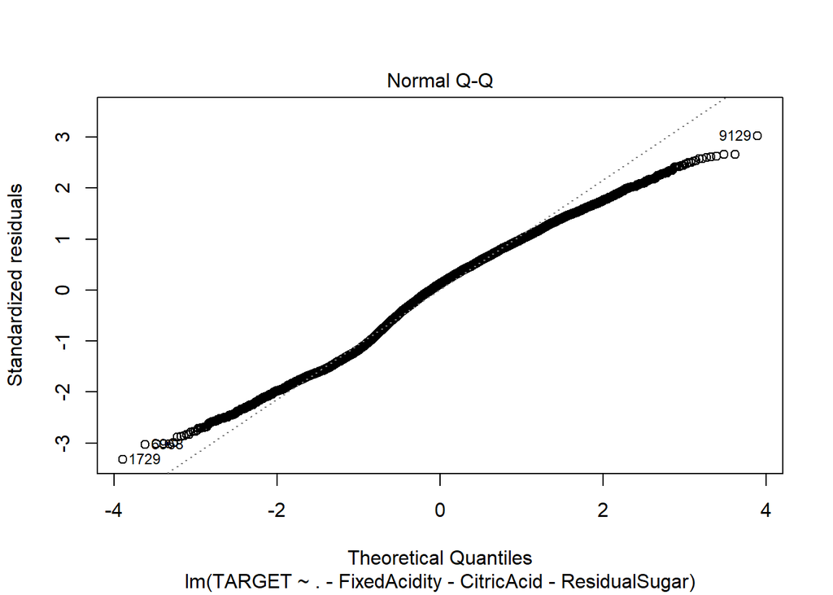

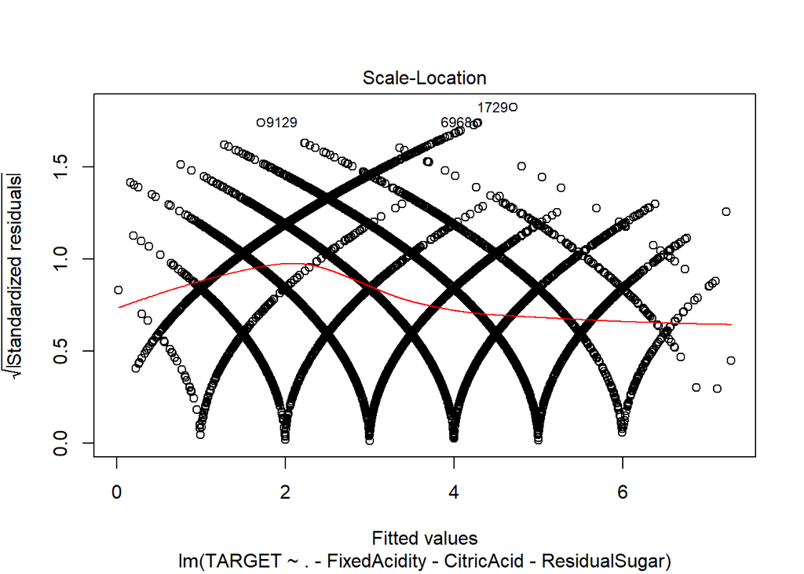

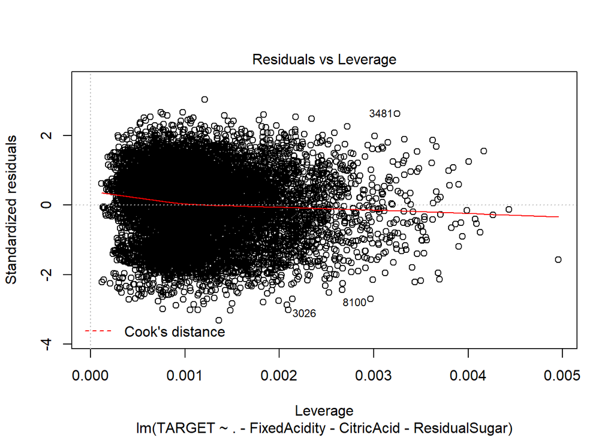

```r
plot(model10)
```

Now lets see the output of the Models using test data:

We will use the squared loss to validate the model.

```r
modelValidation <- function(mod, test){
  preds = predict(mod, test)
  diffMat = as.numeric(preds) - as.numeric(test$TARGET)
  diffMat = diffMat^2
  loss <- mean(diffMat)
  return(loss)
}
```

Poisson model with imputations.

```r
modelValidation(model3, wine_test2)
```

```
## [1] 6.852209
```

Poisson model with imputations and only significant variables.

```r
modelValidation(model4, wine_test2)
```

```
## [1] 6.854547
```

Negative Binomial with imputations:.

```r
modelValidation(model7, wine_test2)
```

```
## [1] 6.852205
```

Negative Binomial with imputations and only significant variables.

```r
modelValidation(model8, wine_test2)
```

```
## [1] 6.854543
```

Linear Model with imputations.

```r
modelValidation(model9, wine_test2)
```

```
## [1] 2.029061
```

Linear Model with imputations and only significant variables.

```r
modelValidation(model10, wine_test2)
```

```
## [1] 2.030002
```

# MODEL SELECTION:

From the above models, i would like to go with Model10 - Linear Model with imputations and only significant variables as it uses less variables and is parsimonious. Also the R2 looks fine. The squared loss is also fine.

# Prediction:

We will use the same method to impute and use log transformation for AcidIndex.

```r
wine_eval <- read.csv("https://raw.githubusercontent.com/Riteshlohiya/Data621-Assignment-5/master/wine_evaluation_data.csv", stringsAsFactors = FALSE)

do_factors <- function(wine_instance){
  wine_instance <- within(wine_instance, {
      LabelAppeal <- factor(LabelAppeal)
      AcidIndex <- factor(AcidIndex)
      STARS <- factor(STARS)
  })
  return (wine_instance)
}
summary(wine_eval)
```

```
##        IN         TARGET         FixedAcidity     VolatileAcidity     CitricAcid
##  Min.   :    3   Mode:logical   Min.   :-18.200   Min.   :-2.8300   Min.   :-3.1200
##  1st Qu.: 4018   NA's:3335      1st Qu.:  5.200   1st Qu.: 0.0800   1st Qu.: 0.0000
##  Median : 7906                  Median :  6.900   Median : 0.2800   Median : 0.3100
##  Mean   : 8048                  Mean   :  6.864   Mean   : 0.3103   Mean   : 0.3124
##  3rd Qu.:12061                  3rd Qu.:  9.000   3rd Qu.: 0.6300   3rd Qu.: 0.6050
##  Max.   :16130                  Max.   : 33.500   Max.   : 3.6100   Max.   : 3.7600
##
##  ResidualSugar        Chlorides        FreeSulfurDioxide TotalSulfurDioxide    Density
##  Min.   :-128.300   Min.   :-1.15000   Min.   :-563.00   Min.   :-769.00    Min.   :0.8898
##  1st Qu.:  -2.600   1st Qu.: 0.01600   1st Qu.:   3.00   1st Qu.:  27.25    1st Qu.:0.9883
##  Median :   3.600   Median : 0.04700   Median :  30.00   Median : 124.00    Median :0.9946
##  Mean   :   5.319   Mean   : 0.06143   Mean   :  34.95   Mean   : 123.41    Mean   :0.9947
##  3rd Qu.:  17.200   3rd Qu.: 0.17100   3rd Qu.:  79.25   3rd Qu.: 210.00    3rd Qu.:1.0005
##  Max.   : 145.400   Max.   : 1.26300   Max.   : 617.00   Max.   :1004.00    Max.   :1.0998
##  NA's   :168        NA's   :138        NA's   :152       NA's   :157
##        pH          Sulphates          Alcohol       LabelAppeal         AcidIndex
##  Min.   :0.600   Min.   :-3.0700   Min.   :-4.20   Min.   :-2.00000   Min.   : 5.000
##  1st Qu.:2.980   1st Qu.: 0.3300   1st Qu.: 9.00   1st Qu.:-1.00000   1st Qu.: 7.000
##  Median :3.210   Median : 0.5000   Median :10.40   Median : 0.00000   Median : 8.000
##  Mean   :3.237   Mean   : 0.5346   Mean   :10.58   Mean   : 0.01349   Mean   : 7.748
##  3rd Qu.:3.490   3rd Qu.: 0.8200   3rd Qu.:12.50   3rd Qu.: 1.00000   3rd Qu.: 8.000
##  Max.   :6.210   Max.   : 4.1800   Max.   :25.60   Max.   : 2.00000   Max.   :17.000
##  NA's   :104     NA's   :310       NA's   :185
##      STARS
##  Min.   :1.00
##  1st Qu.:1.00
##  Median :2.00
##  Mean   :2.04
##  3rd Qu.:3.00
##  Max.   :4.00
##  NA's   :841
```

```r
wine_eval <- mice(wine_eval, m=1, maxit = 5, seed = 42)
wine_eval <- complete(wine_eval)
wine_eval <- as.data.frame(wine_eval)
```

```r
wine_eval$AcidIndex <- log(wine_eval$AcidIndex)
```

```r
wine_eval$TARGET1 <- predict(model10, newdata=wine_eval)
write.csv(wine_eval,"Evaluation_Full_Data.csv", row.names=FALSE)
```